# Stat2017 (Part 2)

2017-Aug-04

## What is regression?

- It's a broad term for a set fo methodologies used to predict a **response** variable (also called a **dependent** or **outcome** variable) from one or more **predictor** variables (also called **independent** or **explanatory** variables).
- In general, regression analysis can be used to **identifiy** the explanatory variables that are related to a response variable, to **describe** the form of the relationships involved, and to **provide** an equation for predicting the response variable from the explanatory variables.

## We'll learn

1. Fit and interpret regression models.
2. Identify potential problems with these models.
3. Variable selection.
4. Generalizability.
5. Relative importance.

## Varieties of regression analysis

| Type of regression | Typical use |
| --- | --- |
| Simpler linear | Predicting a quantitative response variable from a quantitative explanatory variable. |
| Polynomial | Predicting a quantitative response variable from a quantitative explanatory variable, where the relationship is modeled as an *n* th order polynomial. |
| Multiple linear | Predicting a quantitative response variable from two or more explanatory variables. |
| Multilevel | Predicting a response variable from data that have a hierarchical structure (for example, students within classrooms within schools). Also called hierarchical, nested, or mixed models. |

## Varieties of regression analysis

| Type of regression | Typical use |
| --- | --- |
| Multivariate | Predicting more than one response variable from one or more explanatory variables. |
| Logistic | Predicting a categorical response variable from one or more explanatory variables. |
| Poisson | Predicting a response variable representing counts from one or more explanatory variables. |
| Cox proportional hazards | Predicting time to an event (death, failure, relapse) from one or more explanatory variables. |

## Varieties of regression analysis

| Type of regression | Typical use |
| --- | --- |
| Time-series | Modeling time-series data with correlated errors. |
| Nonlinear | Predicting a quantitative response variable from one or more explanatory variables, where the form of the model is nonlinear. |
| Nonparametric | Predicting a quantitative response variable from one or more explanatory variables, where the form of the model is derived from the data and not specified a priori. |
| Robust | Predicting a quantitative response variable from one or more explanatory variables using an approach that’s resistant to the effect of influential observations. |

## Varieties of regression analysis

- We’ll focus on regression methods that fall under the rubric of ordinary least squares (OLS) regression, including **simple linear regression**, **polynomial regression**, and **multiple linear regression**.
- In OLS regression, a **quantitative** dependent variable is predicted from a **weighted sum** of predictor variables, where the weights are parameters estimated from the data.

## Fitting regression models with lm()

```r
myfit <- lm(formula, data)
```

- **formula** describes the model to be fit and **data** is the data frame containing the data to be used in fitting the model.
- The resulting object (**myfit**, in this case) is a *list* that contains extensive information about the fitted model.

## Symbols commonly used in R formulas

| Symbol | Usage |
| --- | --- |
| ~ | Separates response variables on the left from the explanatory variables on the right. For example, a prediction of y from x, z, and w would be coded y ~ x + z + w. |
| + | Separates predictor variables. |
| : | Denotes an interaction between predictor variables. A prediction of y from x, z, and the interaction between x and z would be coded y ~ x + z + x:z. |
| * | A shortcut for denoting all possible interactions. The code y ~ x * z * w expands to y ~ x + z + w + x:z + x:w + z:w + x:z:w. |
| ^ | Denotes interactions up to a specified degree. The code y ~ (x + z + w)^2 expands to y ~ x + z + w + x:z + x:w + z:w. |

## Symbols commonly used in R formulas

[output not shown]

## Useful functions

| Function | Action |
| --- | --- |
| summary() | Displays detailed results for the fitted model |
| coefficients() | Lists the model parameters (intercept and slopes) for the fitted model |
| confint() | Provides confidence intervals for the model parameters (95% by default) |
| fitted() | Lists the predicted values in a fitted model |
| residuals() | Lists the residual values in a fitted model |

## Useful functions

| Function | Action |
| --- | --- |
| anova() | Generates an ANOVA table for a fitted model, or an ANOVA table comparing two or more fitted models |
| vcov() | Lists the covariance matrix for model parameters |
| AIC() | Prints Akaike’s Information Criterion |
| plot() | Generates diagnostic plots for evaluating the fit of a model |
| predict() | Uses a fitted model to predict response values for a new dataset |

## Simple linear regression

```r
fit <- lm(weight ~ height, data=women)
summary(fit)
```

```
Call:
lm(formula = weight ~ height, data = women)

Residuals:
   Min     1Q Median     3Q    Max
-1.733 -1.133 -0.383  0.742  3.117

Coefficients:
            Estimate Std. Error t value Pr(>|t|)
(Intercept) -87.5167     5.9369   -14.7  1.7e-09 ***
height        3.4500     0.0911    37.9  1.1e-14 ***
---
Signif. codes:  0 '***' 0.001 '**' 0.01 '*' 0.05 '.' 0.1 ' ' 1

Residual standard error: 1.53 on 13 degrees of freedom
Multiple R-squared:  0.991, Adjusted R-squared:  0.99
F-statistic: 1.43e+03 on 1 and 13 DF,  p-value: 1.09e-14
```

```r
data.frame(weight = women$weight,
           fitted = fitted(fit),
           residuals = residuals(fit))
```

```
   weight fitted residuals
1     115    113    2.4167
2     117    116    0.9667
3     120    119    0.5167
4     123    123    0.0667
5     126    126   -0.3833
6     129    130   -0.8333
7     132    133   -1.2833
8     135    137   -1.7333
9     139    140   -1.1833
10    142    144   -1.6333
11    146    147   -1.0833
12    150    151   -0.5333
13    154    154    0.0167
14    159    157    1.5667
15    164    161    3.1167
```

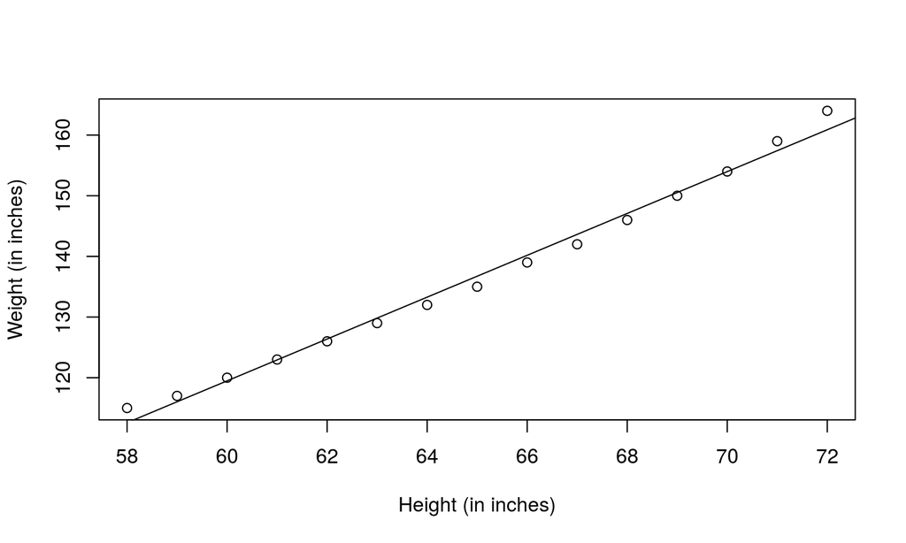

```r
plot(women$height, women$weight,
     xlab='Height (in inches)',
     ylab='Weight (in inches)')
abline(fit)
```

## Polynomial regression

```r
fit2 <- lm(weight ~ height + I(height^2), data=women)
summary(fit2)
```

```
Call:
lm(formula = weight ~ height + I(height^2), data = women)

Residuals:
    Min      1Q  Median      3Q     Max
-0.5094 -0.2961 -0.0094  0.2862  0.5971

Coefficients:
             Estimate Std. Error t value Pr(>|t|)
(Intercept) 261.87818   25.19677   10.39  2.4e-07 ***
height       -7.34832    0.77769   -9.45  6.6e-07 ***
I(height^2)   0.08306    0.00598   13.89  9.3e-09 ***
---
Signif. codes:  0 '***' 0.001 '**' 0.01 '*' 0.05 '.' 0.1 ' ' 1

Residual standard error: 0.384 on 12 degrees of freedom
Multiple R-squared:  0.999, Adjusted R-squared:  0.999
F-statistic: 1.14e+04 on 2 and 12 DF,  p-value: <2e-16
```

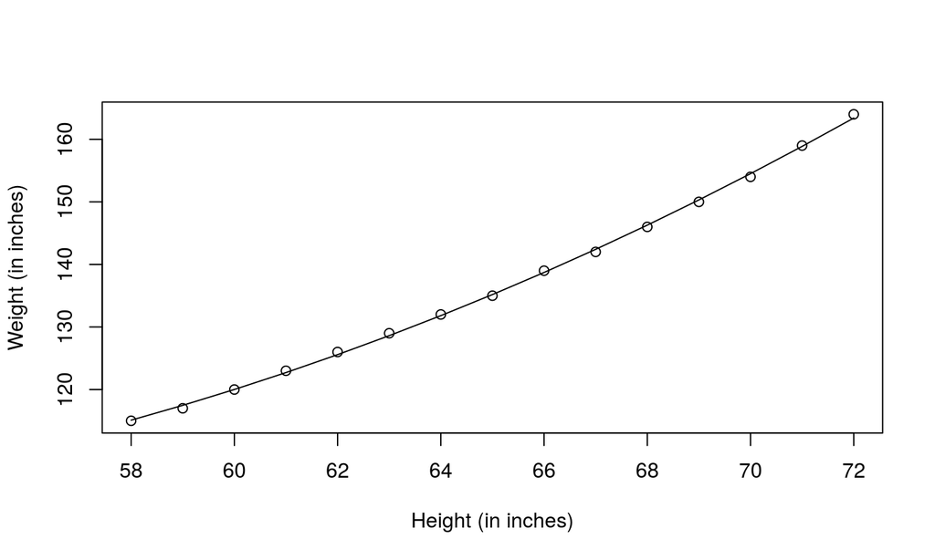

```r
plot(women$height, women$weight,
     xlab='Height (in inches)',
     ylab='Weight (in inches)')
lines(women$height, fitted(fit2))
```

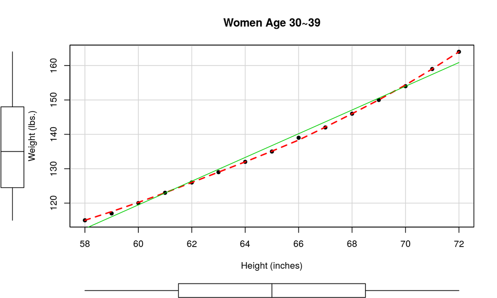

```r
library(car)
scatterplot(weight ~ height, data=women, spread=FALSE, pch=19,
            smoother.args=list(lty=2), main='Women Age 30~39',
            xlab='Height (inches)', ylab='Weight (lbs.)')
```

## Multiple linear regression

A good first step in multiple regression is to examine the relationships among the variables two at a time.

```r
options(digits = 2)
states <- as.data.frame(state.x77[, c("Murder", "Population", "Illiteracy",
                                      "Income", "Frost")])
cor(states)
```

```
           Murder Population Illiteracy Income Frost
Murder       1.00       0.34       0.70  -0.23 -0.54
Population   0.34       1.00       0.11   0.21 -0.33
Illiteracy   0.70       0.11       1.00  -0.44 -0.67
Income      -0.23       0.21      -0.44   1.00  0.23
Frost       -0.54      -0.33      -0.67   0.23  1.00
```

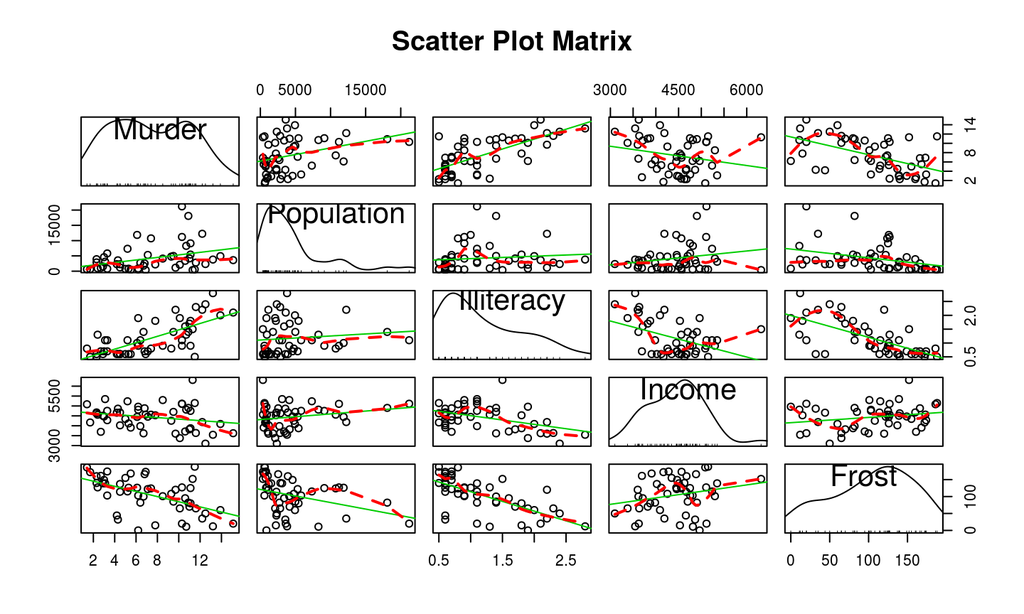

```r
library(car)
scatterplotMatrix(states, spread=FALSE, smoother.args=list(lty=2),
                  main="Scatter Plot Matrix")
```

## Fit the multiple regression model

```r
fit <- lm(Murder ~ Population + Illiteracy + Income + Frost, data=states)
summary(fit)
```

```
Call:
lm(formula = Murder ~ Population + Illiteracy + Income + Frost,
    data = states)

Residuals:
   Min     1Q Median     3Q    Max
-4.796 -1.649 -0.081  1.482  7.621

Coefficients:
            Estimate Std. Error t value Pr(>|t|)
(Intercept) 1.23e+00   3.87e+00    0.32    0.751
Population  2.24e-04   9.05e-05    2.47    0.017 *
Illiteracy  4.14e+00   8.74e-01    4.74  2.2e-05 ***
Income      6.44e-05   6.84e-04    0.09    0.925
Frost       5.81e-04   1.01e-02    0.06    0.954
---
Signif. codes:  0 '***' 0.001 '**' 0.01 '*' 0.05 '.' 0.1 ' ' 1

Residual standard error: 2.5 on 45 degrees of freedom
Multiple R-squared:  0.567, Adjusted R-squared:  0.528
F-statistic: 14.7 on 4 and 45 DF,  p-value: 9.13e-08
```

## Multiple linear regression with interactions

```r
fit <- lm(mpg ~ hp + wt + hp:wt, data=mtcars)
summary(fit)
```

```
Call:
lm(formula = mpg ~ hp + wt + hp:wt, data = mtcars)

Residuals:
   Min     1Q Median     3Q    Max
-3.063 -1.649 -0.736  1.421  4.551

Coefficients:
            Estimate Std. Error t value Pr(>|t|)
(Intercept) 49.80842    3.60516   13.82  5.0e-14 ***
hp          -0.12010    0.02470   -4.86  4.0e-05 ***
wt          -8.21662    1.26971   -6.47  5.2e-07 ***
hp:wt        0.02785    0.00742    3.75  0.00081 ***
---
Signif. codes:  0 '***' 0.001 '**' 0.01 '*' 0.05 '.' 0.1 ' ' 1

Residual standard error: 2.1 on 28 degrees of freedom
Multiple R-squared:  0.885, Adjusted R-squared:  0.872
F-statistic: 71.7 on 3 and 28 DF,  p-value: 2.98e-13
```

You can visualize interactions using the **effect()** function in the **effects** package.

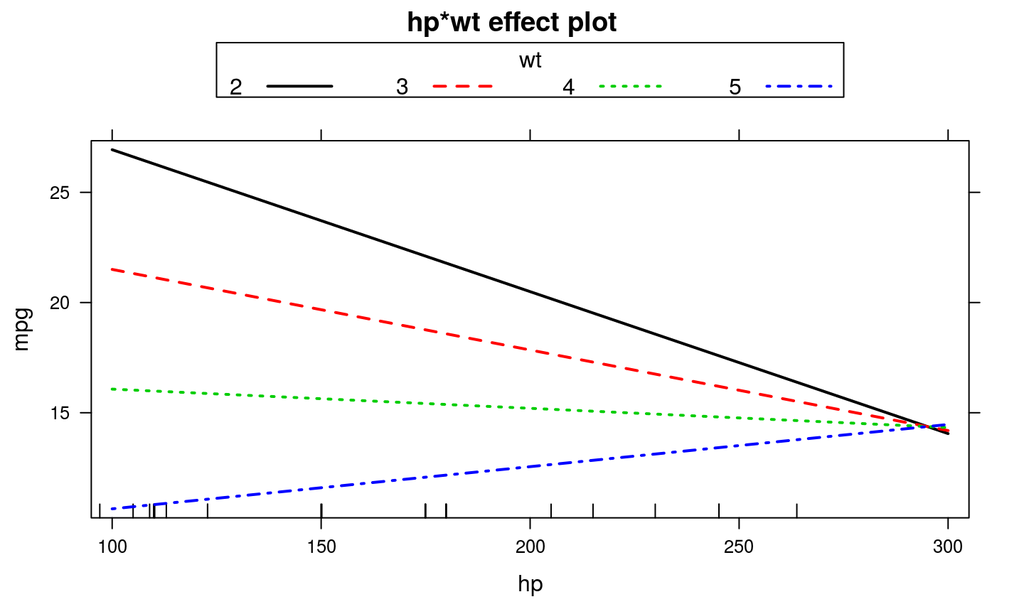

```r
library(effects)
plot(effect("hp:wt", fit), multiline=TRUE)
```

## Regression diagnostics

- Normality
- Independence of errors
- Linearity
- Homoscedasticity

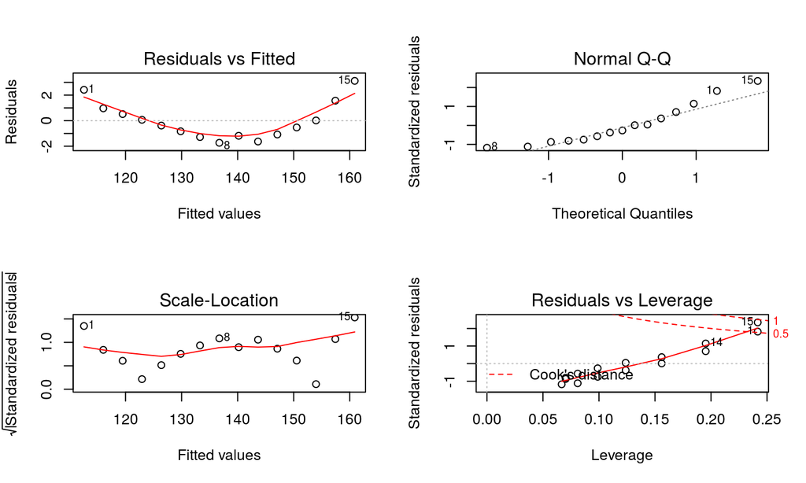

```r
fit <- lm(weight ~ height, data=women)
par(mfrow=c(2,2))
plot(fit)
```

## *Normality*

- If the dependent variable is normally distributed for a fixed set of predictor values, then the residual values should be normally distributed with a mean of 0.
- The **Normal Q-Q plot** is a probability plot of the standardized residuals against the values that would be expected under normality.
- If you’ve met the normality assumption, the points on this graph should fall on the straight 45-degree line.
- If they don’t, you’ve clearly violated the normality assumption.

## *Independence*

- You can’t tell if the dependent variable values are independent from these plots.
- You have to use your understanding of how the data was collected.
- There’s no a priori reason to believe that one woman’s weight influences another woman’s weight.
- If you found out that the data were sampled from families, you might have to adjust your assumption of independence.

## *Linearity*

- If the dependent variable is linearly related to the independent variables, there should be no systematic relationship between the residuals and the predicted (that is, fitted) values.
- In other words, the model should capture all the systematic variance present in the data, leaving nothing but random noise.
- In the **Residuals vs. Fitted graph**, you see clear evidence of a curved relationship, which suggests that you may want to add a quadratic term to the regression.

## *Homoscedasticity*

- If you’ve met the constant variance assumption, the points in the **Scale-Location graph** should be a random band around a horizontal line. You seem to meet this assumption.

```r
library(gvlma)
gvmodel <- gvlma(fit)
g <- summary(gvmodel)
```

```r
g
```

```
                   Value p-value                   Decision
Global Stat        16.59 0.00233 Assumptions NOT satisfied!
Skewness            1.56 0.21200    Assumptions acceptable.
Kurtosis            0.10 0.74961    Assumptions acceptable.
Link Function      14.12 0.00017 Assumptions NOT satisfied!
Heteroscedasticity  0.81 0.36954    Assumptions acceptable.
```

## Outliers

- Outliers are observations that aren’t predicted well by the model. They have unusually large positive or negative residuals.
- A rough rule of thumb is that standardized residuals that are larger than 2 or less than –2 are worth attention.
- The **outlierTest()** function reports the Bonferroni adjusted p-value for the **largest** absolute studentized residual:

```r
library(car)
outlierTest(fit)
```

```
No Studentized residuals with Bonferonni p < 0.05
Largest |rstudent|:
   rstudent unadjusted p-value Bonferonni p
15        3              0.012         0.18
```

If it isn’t significant, there are no outliers in the dataset. If it’s significant, you must **delete** it and **rerun** the test to see if others are present.

## Corrective measures

There are four approaches to dealing with violations of regression assumptions:

- Deleting observations
- Transforming variables
- Adding or deleting variables
- Using another regression approach

## Comparing models

- You can compare the fit of two **nested models** using the **anova()** function in the base installation.
- A nested model is one whose terms are completely included in the other model.
- In the states multiple-regression model, you found that the regression coefficients for *Income* and *Frost* were nonsignificant.
- You can test whether a model without these two variables predicts as well as one that includes them.

```r
states <- as.data.frame(state.x77[,c("Murder", "Population",
                                     "Illiteracy", "Income", "Frost")])
fit1 <- lm(Murder ~ Population + Illiteracy + Income + Frost, data=states)
fit2 <- lm(Murder ~ Population + Illiteracy, data=states)
anova(fit2, fit1)
```

```
Analysis of Variance Table

Model 1: Murder ~ Population + Illiteracy
Model 2: Murder ~ Population + Illiteracy + Income + Frost
  Res.Df RSS Df Sum of Sq    F Pr(>F)
1     47 289
2     45 289  2    0.0785 0.01   0.99
```

- Because the test is nonsignificant, you conclude that they don’t add to the linear prediction and you’re justified in dropping them from your model.
- The Akaike Information Criterion (AIC) provides another method for comparing models.
- Models with smaller AIC values are preferred.

```r
states <- as.data.frame(state.x77[,c("Murder", "Population",
                                     "Illiteracy", "Income", "Frost")])
fit1 <- lm(Murder ~ Population + Illiteracy + Income + Frost, data=states)
fit2 <- lm(Murder ~ Population + Illiteracy, data=states)
AIC(fit2, fit1)
```

```
     df AIC
fit2  4 238
fit1  6 242
```

- Note that although the ANOVA approach requires nested models, the AIC approach doesn’t.

## Variable selection

- All subsets regression is performed using the **regsubsets()** function from the **leaps** package.
- You can choose the R-squared, Adjusted R-squared, or Mallows Cp statistic as your criterion for reporting “best” models.
- It has been widely suggested that a good model is one in which the Cp statistic is close to the number of model parameters (including the intercept).

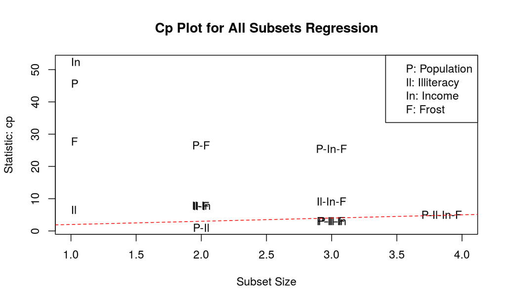

```r
library(leaps)
states <- as.data.frame(state.x77[,c("Murder", "Population",
                                     "Illiteracy", "Income", "Frost")])
leaps <-regsubsets(Murder ~ Population + Illiteracy + Income + Frost, data=states, nbest=4)
library(car)
subsets(leaps, statistic="cp", main="Cp Plot for All Subsets Regression", legend = 'topright')
abline(1,1,lty=2,col="red")
```

- Better models will fall close to a (red) line with intercept 1 and slope 1.

## Cross-validation

- Cross-validation is a useful method for evaluating the generalizability of a regression equation.
- In *k-fold cross-validation*, the sample is divided into *k* subsamples. Each of the *k* subsamples serves as a hold-out group, and the combined observations from the remaining *k* – 1 subsamples serve as the training group.
- The performance for the *k* prediction equations applied to the *k* hold-out samples is recorded and then averaged.
- When *k* equals *n*, the total number of observations, this approach is called *jackknifing*.

## Cross-validation

- You can perform k-fold cross-validation using the **crossval()** function in the **bootstrap** package.
- The following listing provides a function (called shrinkage() ) for cross-validating a model’s R-square statistic using k-fold cross-validation.

```r
shrinkage <- function(fit, k=10){
  require(bootstrap)
  theta.fit <- function(x,y){lsfit(x,y)}
  theta.predict <- function(fit,x){cbind(1,x)%*%fit$coef}
  x <- fit$model[,2:ncol(fit$model)]
  y <- fit$model[,1]
  results <- crossval(x, y, theta.fit, theta.predict, ngroup=k)
  r2 <- cor(y, fit$fitted.values)^2
  r2cv <- cor(y, results$cv.fit)^2
  cat("Original R-square =", r2, "\n")
  cat(k, "Fold Cross-Validated R-square =", r2cv, "\n")
  cat("Change =", r2-r2cv, "\n")
}
```

```r
states <- as.data.frame(state.x77[,c("Murder", "Population",
                                     "Illiteracy", "Income", "Frost")])
fit <- lm(Murder ~ Population + Income + Illiteracy + Frost, data=states)
shrinkage(fit)
```

```
Original R-square = 0.57
10 Fold Cross-Validated R-square = 0.49
Change = 0.075
```

```r
fit2 <- lm(Murder ~ Population + Illiteracy,data=states)
shrinkage(fit2)
```

```
Original R-square = 0.57
10 Fold Cross-Validated R-square = 0.52
Change = 0.05
```

## Relative importance

- There have been many attempts to develop a means for assessing the relative importance of predictors. The simplest has been to compare standardized regression coefficients.
- Standardized regression coefficients describe the expected change in the response variable (expressed in standard deviation units) for a standard deviation change in a predictor variable, holding the other predictor variables constant.

```r
states <- as.data.frame(state.x77[,c("Murder", "Population",
                                     "Illiteracy", "Income", "Frost")])
zstates <- as.data.frame(scale(states))
zfit <- lm(Murder~Population + Income + Illiteracy + Frost, data=zstates)
coef(zfit)
```

```
(Intercept)  Population      Income  Illiteracy       Frost
   -2.1e-16     2.7e-01     1.1e-02     6.8e-01     8.2e-03
```

## Summary

- Regression analysis is a process with many parts.
- We’ve discussed fitting OLS regression models, using regression diagnostics to assess the data’s fit to statistical assumptions, and methods for modifying the data to meet these assumptions more closely.
- We looked at ways of selecting a final regression model from many possible models, and you learned how to evaluate its likely performance on new samples of data.
- Finally, we tackled the thorny problem of variable importance: identifying which variables are the most important for predicting an outcome.
- In each of the examples, the predictor variables have been quantitative. However, there are no restrictions against using categorical variables as predictors as well.
- Using a categorical predictor such as gender, treatment type, or manufacturing process allows you to examine group differences on a response or outcome variable. This is the focus of our next part: ANOVA.

[figure not shown]